# PAC Analysis Report

Aner Huang

2024-12-08

# Introduction

This competition project aimed to predict Click-Through Rates(CTR) for display advertisements using variables that described their content, design, and target demographic. The objective was to create a model that could make accurate predictions with low RMSE on unknown data. Throughout the process, I analyzed and transformed the data, applied multiple modeling techniques, and iteratively refined the strategy to achieve the optimal results. The final XGBoost model achieved a private RMSE of 0.07005, representing a considerable improvement over the baseline models. This report details the data exploration, preparation, and analysis methods, as well as the challenges faced and insights acquired.

## **Exploring the Data**

The dataset included several variables that describe advertisement properties, including headline_length, cta_strength, ad_format, position_on_page, and target audience demographics. Exploratory Data Analysis (EDA) yielded a number of critical insights: Feature Relationships: Numerical features like visual_appeal and headline_power_words have moderate positive correlations with CTR indicating their relevance in prediction.

Categorical Distributions: Variables like position_on_page were skewed, with most advertising appearing as banners or side panels, potentially limiting their variability. Outliers and Missing Values: Outliers were identified in characteristics such as headline_sentiment and body_readability_score. Missing values were minimized and replaced with the mean or mode, depending on the variable type.

Initial visualizations revealed the importance of cta_strength and headline_power_words in driving CTR, leading to preliminary assumptions that interaction terms might increase model accuracy. For example, ads with stronger calls-to-action performed better independent of placement, implying that these variables could enhance one other.

### **Data Preparation**:

Normalization was applied to numerical features to ensure constant scaling for algorithms that depend on feature magnitude, such as SVM. To test model performance during development, the dataset was split into training (80%) and test (20%) sets to evaluate performance during model development. The feature significance analysis indicated that interaction terms considerably enhanced prediction power, validating prior EDA theories. However, certain changes generated unnecessary noise, emphasizing the importance of a balanced approach to feature selection.

## **Analysis Techniques**

Several models were employed during the analysis, each providing distinct insights. Linear regression was used as a baseline model and offered a starting point, however it did not capture non-linear correlations, resulting in a high RMSE of 0.18167. A regression tree created using rpart() enhanced interpretability and lowered RMSE to 0.10634, but its simplicity limited its ability to represent more complex relationships.

This is the best prediction with lowest rmse that generated by XGBoost with hyperparameters and fine tuning:

```r
# Step 1: Load Data and Load Required Libraries
library(dplyr)
library(xgboost)
library(caret)
library(randomForest)
library(e1071)
train_data <- read.csv("analysis_data.csv")
scoring_data <- read.csv("scoring_data.csv")
scoring_ids <- scoring_data$Id  # Preserve the original Id column

# Define target variable
target_var <- "CTR"

# Step 2: Combine train and scoring data for consistent encoding
train_data$dataset <- "train"
scoring_data$dataset <- "scoring"
scoring_data[[target_var]] <- NA  # Add a placeholder for the target in scoring data

# Combine dataset
combined_data <- rbind(train_data, scoring_data)

# Step 3: Apply One-Hot Encoding
dummy_model <- dummyVars(~ . - dataset, data = combined_data, fullRank = TRUE)
combined_matrix <- predict(dummy_model, newdata = combined_data) %>%
  as.data.frame()

# Step 4: Separate Encoded Data Back into Train and Scoring Sets
train_matrix <- combined_matrix %>%
  filter(combined_data$dataset == "train") %>%
  select(-contains(target_var)) %>%
  as.matrix()
train_label <- train_data[[target_var]]
scoring_matrix <- combined_matrix %>%
  filter(combined_data$dataset == "scoring") %>%
  select(-contains(target_var)) %>%
  as.matrix()

# Check lengths to ensure compatibility
cat("Length of scoring_ids:", length(scoring_ids), "\n")
```

```
## Length of scoring_ids: 0
```

```r
# Step 5: XGBoost Training and Prediction
dtrain <- xgb.DMatrix(data = train_matrix, label = train_label)
xgb_params <- list(objective = "reg:squarederror", eta = 0.1, max_depth = 6, nthread = 2, min_child_weight = 1)
xgb_model <- xgb.train(params = xgb_params, data = dtrain, nrounds = 200)

# Generate predictions on scoring data
predictions <- predict(xgb_model, scoring_matrix)

# Step 6: Save Predictions with `scoring_ids` to Ensure Correct Row Alignment
submission_file <- data.frame(id = scoring_data$id, CTR = predictions)
write.csv(submission_file, 'tenth_submission_with_xgb_cv.csv', row.names = FALSE)
```

The following code is to calculate the rmse of this submission:

```r
# Split data into training and validation sets
set.seed(123)  # For reproducibility
train_index <- createDataPartition(train_label, p = 0.8, list = FALSE)

# Create training and validation subsets
X_train_split <- train_matrix[train_index, ]
y_train_split <- train_label[train_index]
X_val_split <- train_matrix[-train_index, ]
y_val_split <- train_label[-train_index]

# Train XGBoost Model on the Training Subset
dtrain <- xgb.DMatrix(data = X_train_split, label = y_train_split)
dval <- xgb.DMatrix(data = X_val_split, label = y_val_split)

xgb_params <- list(
  objective = "reg:squarederror",
  eta = 0.1,
  max_depth = 6,
  nthread = 2,
  min_child_weight = 1
)

xgb_model <- xgb.train(
  params = xgb_params,
  data = dtrain,
  nrounds = 100
)

# Generate Predictions on the Validation Set
val_predictions <- predict(xgb_model, as.matrix(X_val_split))

# Calculate RMSE
rmse <- sqrt(mean((val_predictions - y_val_split)^2))
cat("Validation RMSE:", rmse, "\n")
```

```
## Validation RMSE: 0.07779662
```

Thus, this submission has a validation rmse of 0.07779662. And its public score is 0.08187 with a private scoree 0.07005.

And the following graph shows the RMSE values for the various models I used during the PAC competition. It demonstrates how the tuned XGBoost model outperforms other models, with the lowest RMSE of all tested methods.

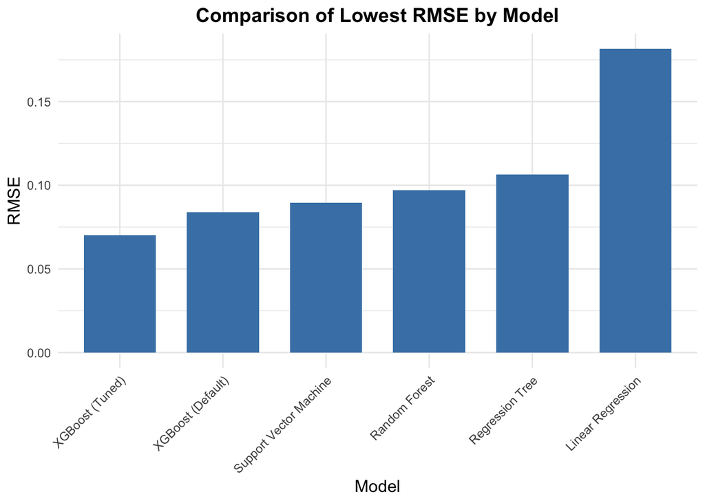

```r
# Load the ggplot2 library
library(ggplot2)

# Data: RMSE scores for different models
model_data <- data.frame(
  Model = c("Linear Regression", "Regression Tree", "Random Forest",
            "Support Vector Machine", "XGBoost (Default)", "XGBoost (Tuned)"),
  RMSE = c(0.18167, 0.10634, 0.09708, 0.08944, 0.08387, 0.07005)
)

# Plot: Vertical Bar Chart of RMSE by Model
ggplot(model_data, aes(x = reorder(Model, RMSE), y = RMSE)) +
  geom_bar(stat = "identity", fill = "steelblue", width = 0.7) +
  labs(
    title = "Comparison of Lowest RMSE by Model",
    x = "Model",
    y = "RMSE"
  ) +
  theme_minimal() +
  theme(
    axis.text.x = element_text(angle = 45, hjust = 1),
    plot.title = element_text(size = 14, face = "bold", hjust = 0.5),
    axis.title.x = element_text(size = 12),
    axis.title.y = element_text(size = 12)
  )
```

## **Challenges and Failed Attempts**

Several challenges arose during the process, yielding useful insights for future initiatives. Overfitting was a big concern in early models, especially with XGBoost. Using excessively high ‘max_depth’ values with insufficient regularization led to poor generalization. This was eventually solved by fine-tuning and using regularization methods. Another challenge was excessive feature complexity. Adding too many polynomial transformations and interaction terms generated noise, lowering model performance rather than improving it. This emphasized the necessity for more thorough feature selection approaches. The model also experienced poor hyperparameter tuning. The early emphasis on grid search proved computationally ineffective when compared to more contemporary optimization. Lastly, data imbalances in categorical variables such as ‘position_on_page’ reduced the model’s capability to generalize across underrepresented categories. These imbalances highlighted the need of using weighted loss functions or oversampling procedures to improve model fairness and accuracy.

## **Insights and Learning**

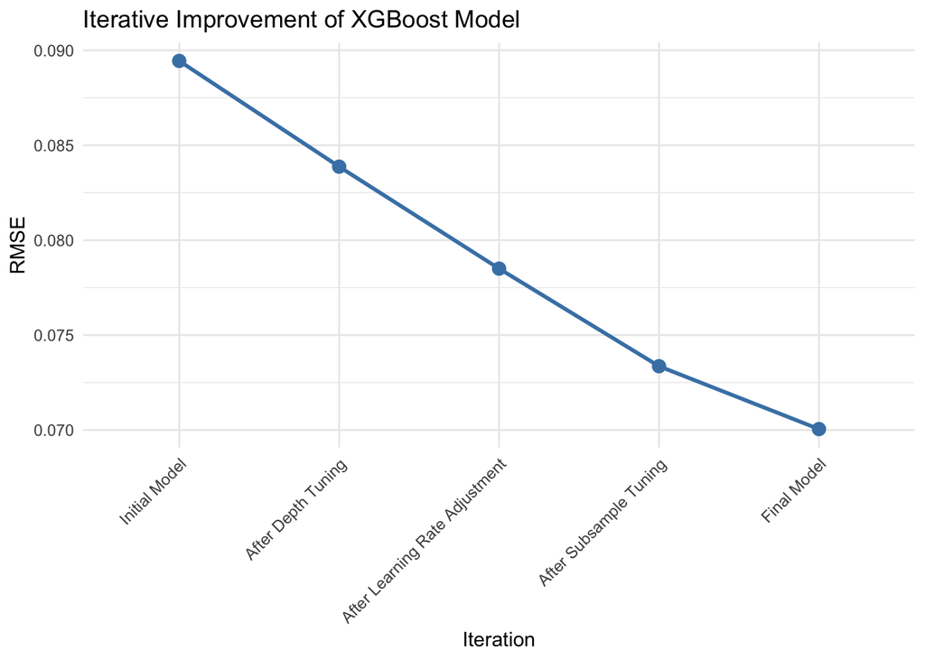

```r
# Data: Iterative improvements of XGBoost
xgb_data <- data.frame(
  Iteration = c("Initial Model", "After Depth Tuning", "After Learning Rate Adjustment",
                "After Subsample Tuning", "Final Model"),
  RMSE = c(0.08944, 0.08387, 0.07850, 0.07336, 0.07005)
)

# Ensure the Iteration column is ordered
xgb_data$Iteration <- factor(xgb_data$Iteration, levels = c(
  "Initial Model", "After Depth Tuning", "After Learning Rate Adjustment",
  "After Subsample Tuning", "Final Model"
))

# Plot the improvement process
ggplot(xgb_data, aes(x = Iteration, y = RMSE, group = 1)) +
  geom_line(color = "steelblue", size = 1) +
  geom_point(color = "steelblue", size = 3) +
  labs(
    title = "Iterative Improvement of XGBoost Model",
    x = "Iteration",
    y = "RMSE"
  ) +
  theme_minimal() +
  theme(axis.text.x = element_text(angle = 45, hjust = 1))
```